# Import Necessary libraies

```python
# Import Necessary libraries
import pandas as pd
import numpy as np
import matplotlib.pyplot as plt

from sklearn.model_selection import train_test_split, GridSearchCV
from sklearn.metrics import roc_curve, auc
from sklearn.metrics import precision_score, recall_score, f1_score
from sklearn.metrics import confusion_matrix
from sklearn.preprocessing import StandardScaler

from sklearn.dummy import DummyClassifier
from sklearn.linear_model import LogisticRegression
from sklearn.neighbors import KNeighborsClassifier
from sklearn.naive_bayes import GaussianNB, BernoulliNB, MultinomialNB
from sklearn.ensemble import RandomForestClassifier, BaggingClassifier, AdaBoostClassifier, ExtraTreesClassifier, VotingClassifier
from sklearn.svm import LinearSVC, NuSVC, SVC
from sklearn.neural_network import MLPClassifier
from sklearn.cluster import k_means

import itertools
from datetime import datetime

# Confiure constants
from pylab import rcParams
rcParams['figure.figsize'] = 10, 5
```

# Import Data

```python
# Import the raw_data
raw_data = pd.read_csv("./credit card.csv")
```

# Basic look at the attributes

```python
compare_data_0 = raw_data[raw_data['default payment next month'] == 0]
compare_data_1 = raw_data[raw_data['default payment next month'] == 1]

c0_l = len(compare_data_0)
c1_l = len(compare_data_1)

print("Ontime: "+str(c0_l))
print("Delay: "+str(c1_l))
```

```
Ontime: 23364
Delay: 6636
```

### Gender may have some impact on Default Payment

```python
# See if Gender have a Big difference - There are some differences

M_0 = len(compare_data_0[compare_data_0['SEX'] == 1])
F_0 = len(compare_data_0[compare_data_0['SEX'] == 2])
M_1 = len(compare_data_1[compare_data_1['SEX'] == 1])
F_1 = len(compare_data_1[compare_data_1['SEX'] == 2])

print("Male-ontime %: "+str(M_0/c0_l))
print("Female-ontime %: "+str(F_0/c0_l))
print("===================")
print("Male-delay %: "+str(M_1/c1_l))
print("Female-delay %: "+str(F_1/c1_l))
```

```
Male-ontime %: 0.38585002568053417
Female-ontime %: 0.6141499743194658
===================
Male-delay %: 0.43294153104279687
Female-delay %: 0.5670584689572031
```

### Education doesn't seem to have a lot of impact on Default Payment

```python
# See if EDUCATION have a Big difference - Not really

e1_0 = len(compare_data_0[compare_data_0['EDUCATION'] == 1])
e2_0 = len(compare_data_0[compare_data_0['EDUCATION'] == 2])
e3_0 = len(compare_data_0[compare_data_0['EDUCATION'] == 3])
e4_0 = len(compare_data_0[compare_data_0['EDUCATION'] >= 4])
e0 = [e1_0,e2_0,e3_0,e4_0]

e1_1 = len(compare_data_1[compare_data_1['EDUCATION'] == 1])
e2_1 = len(compare_data_1[compare_data_1['EDUCATION'] == 2])
e3_1 = len(compare_data_1[compare_data_1['EDUCATION'] == 3])
e4_1 = len(compare_data_1[compare_data_1['EDUCATION'] >= 4])
e1 = [e1_1,e2_1,e3_1,e4_1]

labels = ["graduate school", "university", "high school", "others"]

for i in range(0,4):
    print(labels[i]+" ontime %: "+str(e0[i]/c0_l))

print("===================")

for i in range(0,4):
    print(labels[i]+" delay %: "+str(e1[i]/c1_l))
```

```
graduate school ontime %: 0.36590481082006504
university ontime %: 0.4579695257661359
high school ontime %: 0.15750727615134394
others ontime %: 0.018019174798835816
===================
graduate school delay %: 0.30681133212778783
university delay %: 0.5018083182640145
high school delay %: 0.18640747438215793
others delay %: 0.004972875226039783
```

### Marriage doesn't seem to have a lot of impact on Default Payment

```python
# See if Marriage have a Big difference - Not really

m1_0 = len(compare_data_0[compare_data_0['MARRIAGE'] == 1])
m2_0 = len(compare_data_0[compare_data_0['MARRIAGE'] == 2])
m3_0 = len(compare_data_0[compare_data_0['MARRIAGE'] == 3])
m0 = [m1_0,m2_0,m3_0]

m1_1 = len(compare_data_1[compare_data_1['MARRIAGE'] == 1])
m2_1 = len(compare_data_1[compare_data_1['MARRIAGE'] == 2])
m3_1 = len(compare_data_1[compare_data_1['MARRIAGE'] == 3])
m1 = [m1_1,m2_1,m3_1]

labels = ["married", "single", "others"]

for i in range(0,3):
    print(labels[i]+" ontime %: "+str(m0[i]/c0_l))

print("===================")

for i in range(0,3):
    print(labels[i]+" delay %: "+str(m1[i]/c1_l))
```

```
married ontime %: 0.44739770587228217
single ontime %: 0.5402756377332648
others ontime %: 0.010229412771785653
===================
married delay %: 0.4831223628691983
single delay %: 0.503465943339361
others delay %: 0.012658227848101266
```

# Write a Function Used to Evaluate Each Model

- Can Input Any sklearn Model
- Can choose the amount of runs to run (Default 3), with data re-splited and model re-trained.
- Will Output the Accuracy / Precision / Recall / F1 score of each run
- Will Return the average accuracy of the runs
- Can Select Different Subsets of Data (Default choose all)
- Can Choose to Scale the Data or Not (Default not to scale)
- Can draw CONFUSION_MATRIX / ROC Curve

```python
# Test Function to evaluate each model and produce scoring / ROC curve / Confusion matrix
def evalute_model(model, RUNS=3, TAG="TEST MODEL", data_selection="1111111", draw_CONFUSION_MATRIX=False, draw_ROC=False, SCALE=False):
    model_scores = []
    # Run for a number of runs
    for i in range(0,RUNS):
        # Split data into training and testing data
        train_data, test_data = train_test_split(raw_data, test_size=0.3)

        LIMIT = ['LIMIT_BAL']
        SEX = ['SEX']
        GENERAL_LIST = ['EDUCATION', 'MARRIAGE']
        AGE = ['AGE']
        PAY = ['PAY_0', 'PAY_2', 'PAY_3', 'PAY_4', 'PAY_5', 'PAY_6']
        BILL_AMT = ['BILL_AMT1', 'BILL_AMT2', 'BILL_AMT3', 'BILL_AMT4', 'BILL_AMT5', 'BILL_AMT6']
        PAY_AMT = ['PAY_AMT1', 'PAY_AMT2', 'PAY_AMT3', 'PAY_AMT4', 'PAY_AMT5', 'PAY_AMT6']

        DATA_LIST = []
        if data_selection[0]=="1":
            DATA_LIST = DATA_LIST + LIMIT
        if data_selection[1]=="1":
            DATA_LIST = DATA_LIST + SEX
        if data_selection[2]=="1":
            DATA_LIST = DATA_LIST + GENERAL_LIST
        if data_selection[3]=="1":
            DATA_LIST = DATA_LIST + AGE
        if data_selection[4]=="1":
            DATA_LIST = DATA_LIST + PAY
        if data_selection[5]=="1":
            DATA_LIST = DATA_LIST + BILL_AMT
        if data_selection[6]=="1":
            DATA_LIST = DATA_LIST + PAY_AMT

        # Select the X and Y of the training and testing data
        train_data_X = train_data[DATA_LIST]
        train_data_Y = train_data[['default payment next month']]
        test_data_X = test_data[DATA_LIST]
        test_data_Y = test_data[['default payment next month']]

        if SCALE:
            scaler = StandardScaler()
            scaler.fit(train_data_X)
            train_data_X = scaler.transform(train_data_X)
            test_data_X = scaler.transform(test_data_X)

        # Fit the current model
        model.fit(train_data_X, train_data_Y.values.ravel())

        # Calculate the scores
        run_score = {}
        run_score['score'] = model.score(test_data_X, test_data_Y.values.ravel())
        m_p = model.predict(test_data_X)
        if 0 in m_p and 1 in m_p:
            run_score['precision'] = precision_score(test_data_Y, m_p)
            run_score['recall'] = recall_score(test_data_Y, m_p)
            run_score['f1'] = f1_score(test_data_Y, m_p)
        elif 0 in m_p:
            print("RUN "+str(i+1)+": All predicted labels are 0!")
        else:
            print("All predicted labels are 1!")
        model_scores.append(run_score)

    # Print out results
    print("========== "+str(TAG)+" ==========")
    total = 0
    for run in model_scores:
        print("Accuracy: {:>10f} / Precision: {:>10f} / Recall: {:>10f} / F1 Score: {:>10f}".format( \
            run.get('score', 0), run.get('precision', 0), run.get('recall', 0), run.get('f1', 0)))
        total = total + run['score']
    print("AVG SCORE in "+str(RUNS)+" runs: "+str(total/RUNS))
    print("="*(len(TAG)+22))

    # Set Return Value
    ret = total/RUNS

    # Draw Confusion Matrix if needed
    if draw_CONFUSION_MATRIX:
        # Contriants
        COLOR_MAP = plt.cm.Blues
        CLASSES = ["PAY", "Not PAY"]
        # Calculate Confusion Matrix with and without normalization
        c_m = confusion_matrix(test_data_Y, m_p)
        c_m_norm = c_m.astype('float') / c_m.sum(axis=1)[:, np.newaxis]
        # PLOT Confusion Matrix without normalization
        plt.subplot(1, 2, 1)
        plt.imshow(c_m, interpolation='nearest', cmap=COLOR_MAP)
        plt.title(str(TAG))
        plt.colorbar()
        tick_marks = np.arange(len(CLASSES))
        plt.xticks(tick_marks, CLASSES, rotation=45)
        plt.yticks(tick_marks, CLASSES)
        for i, j in itertools.product(range(c_m.shape[0]), range(c_m.shape[1])):
            plt.text(j, i, c_m[i, j], horizontalalignment="center", color="white" if c_m[i, j] > (c_m.max()/2.0) else "black")
        plt.ylabel('True label')
        plt.xlabel('Predicted label')
        # PLOT Confusion Matrix with normalization
        plt.subplot(1, 2, 2)
        plt.imshow(c_m_norm, interpolation='nearest', cmap=COLOR_MAP)
        plt.title(str(TAG)+" Normalized")
        plt.colorbar()
        tick_marks = np.arange(len(CLASSES))
        plt.xticks(tick_marks, CLASSES, rotation=45)
        plt.yticks(tick_marks, CLASSES)
        for i, j in itertools.product(range(c_m_norm.shape[0]), range(c_m_norm.shape[1])):
            plt.text(j, i, c_m_norm[i, j], horizontalalignment="center", color= \
                "white" if c_m_norm[i, j] > (c_m_norm.max()/2.0) else "black")
        plt.ylabel('True label')
        plt.xlabel('Predicted label')
        # Tight Layout to prevent label overlay
        plt.tight_layout()
        plt.show()

    # Draw ROC curve if needed
    if draw_ROC:
        # Calculate False positive rate and True positive rate using data from last RUN
        fpr, tpr, thresholds = roc_curve(test_data_Y.values.ravel(), model.predict_proba(test_data_X)[:,[1]])
        roc_auc = auc(fpr, tpr)
        plt.plot(fpr, tpr, color='darkorange', lw=2, label='ROC curve (area = %0.3f)' % roc_auc)
        plt.plot([0, 1], [0, 1], color='navy', lw=2, linestyle='--')
        plt.xlim([0.0, 1.0])
        plt.ylim([0.0, 1.0])
        plt.xlabel('False Positive Rate')
        plt.ylabel('True Positive Rate')
        plt.legend(loc="lower right")
        plt.title("ROC curve of "+str(TAG))
        plt.show()

    return ret
```

# Dummy Classifer (Reference)

```
========== DUMMY Model ==========
Accuracy:   0.659111 / Precision:   0.219067 / Recall:   0.218513 / F1 Score:   0.218790
Accuracy:   0.656778 / Precision:   0.219437 / Recall:   0.215145 / F1 Score:   0.217270
Accuracy:   0.647222 / Precision:   0.227979 / Recall:   0.218471 / F1 Score:   0.223124
AVG SCORE in 3 runs: 0.65437037037
=================================
```

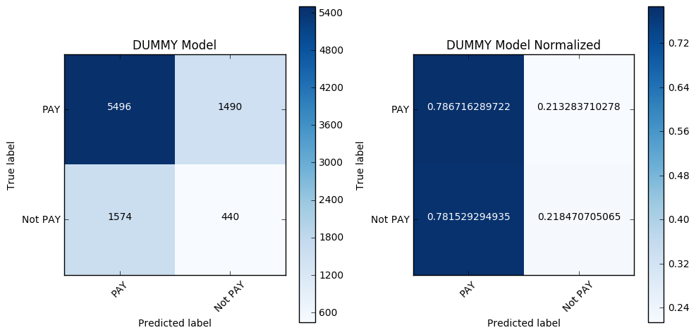

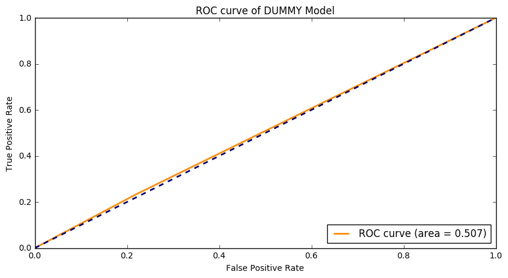

```python
DUM_model = DummyClassifier()
s = evalute_model(DUM_model, TAG="DUMMY Model", data_selection="1111111", draw_CONFUSION_MATRIX=True, draw_ROC=True, RUNS=3)
```

```
RUN 1: All predicted labels are 0!
RUN 2: All predicted labels are 0!
RUN 3: All predicted labels are 0!
========== DUMMY Model ==========
Accuracy:   0.779444 / Precision:   0.000000 / Recall:   0.000000 / F1 Score:   0.000000
Accuracy:   0.780111 / Precision:   0.000000 / Recall:   0.000000 / F1 Score:   0.000000
Accuracy:   0.781778 / Precision:   0.000000 / Recall:   0.000000 / F1 Score:   0.000000
AVG SCORE in 3 runs: 0.780444444444
=================================
```

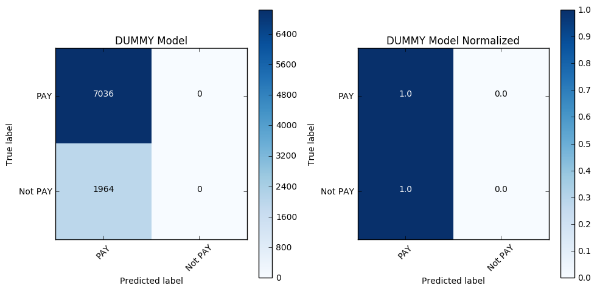

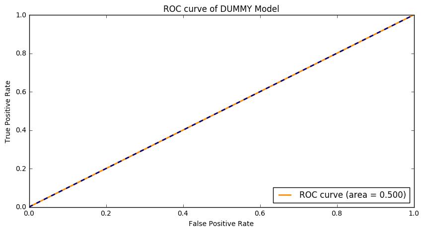

```python
DUM_model = DummyClassifier(strategy="most_frequent")
s = evalute_model(DUM_model, TAG="DUMMY Model", data_selection="1111111", draw_CONFUSION_MATRIX=True, draw_ROC=True, RUNS=3)
```

# Logistic Regression

```
========== Logistic Regression Model ==========
Accuracy:   0.812444 / Precision:   0.738794 / Recall:   0.239359 / F1 Score:   0.361573
Accuracy:   0.810556 / Precision:   0.724891 / Recall:   0.247269 / F1 Score:   0.368752
Accuracy:   0.810111 / Precision:   0.699430 / Recall:   0.246858 / F1 Score:   0.364920
AVG SCORE in 3 runs: 0.811037037037
===============================================
```

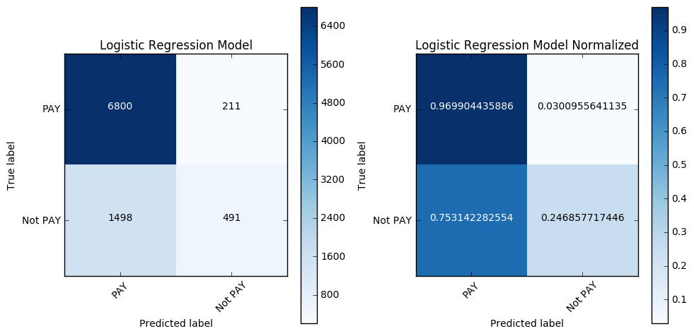

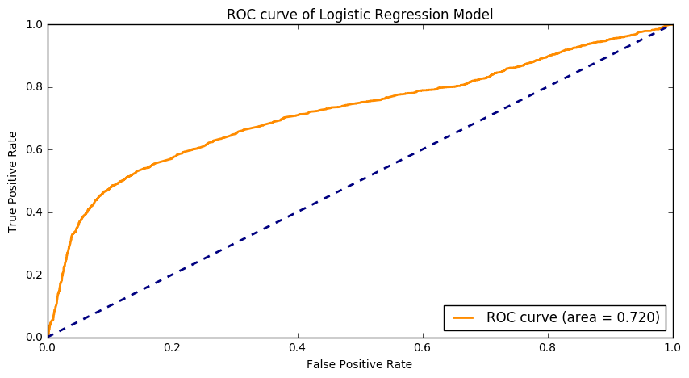

```python
LR_model = LogisticRegression(penalty='l2', C=1000)
s = evalute_model(LR_model, TAG="Logistic Regression Model", data_selection="1100100", SCALE=True, draw_CONFUSION_MATRIX=True, draw_ROC=True)
```

# k-Nearest Neighbors

```
========== k-Nearest Neighbors Model ==========
Accuracy:   0.815778 / Precision:   0.652827 / Recall:   0.368762 / F1 Score:   0.471301
Accuracy:   0.822667 / Precision:   0.713220 / Recall:   0.335170 / F1 Score:   0.456033
Accuracy:   0.823222 / Precision:   0.687688 / Recall:   0.349440 / F1 Score:   0.463406
AVG SCORE in 3 runs: 0.820555555556
===============================================
```

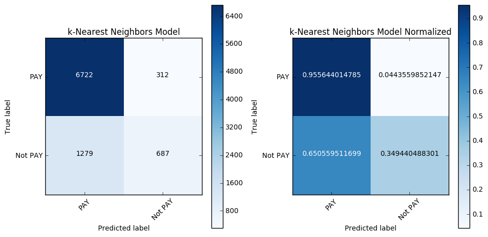

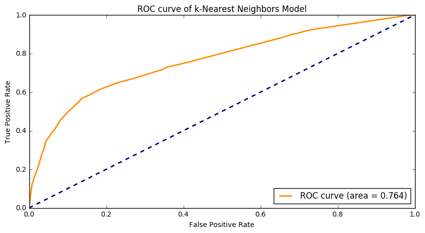

```python
kNN_model = KNeighborsClassifier(n_neighbors=100, weights='uniform')
s = evalute_model(kNN_model, TAG="k-Nearest Neighbors Model", data_selection="0100100", draw_CONFUSION_MATRIX=True, draw_ROC=True)
```

```
========== k-Nearest Neighbors Model ==========
Accuracy:   0.815000 / Precision:   0.647059 / Recall:   0.359296 / F1 Score:   0.462036
Accuracy:   0.817778 / Precision:   0.665706 / Recall:   0.349118 / F1 Score:   0.458030
Accuracy:   0.815778 / Precision:   0.677291 / Recall:   0.337637 / F1 Score:   0.450630
AVG SCORE in 3 runs: 0.816185185185
===============================================
```

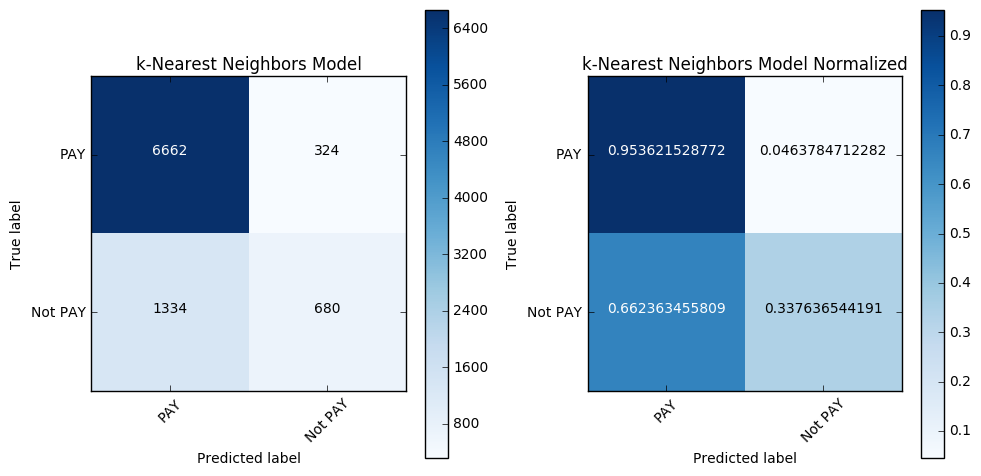

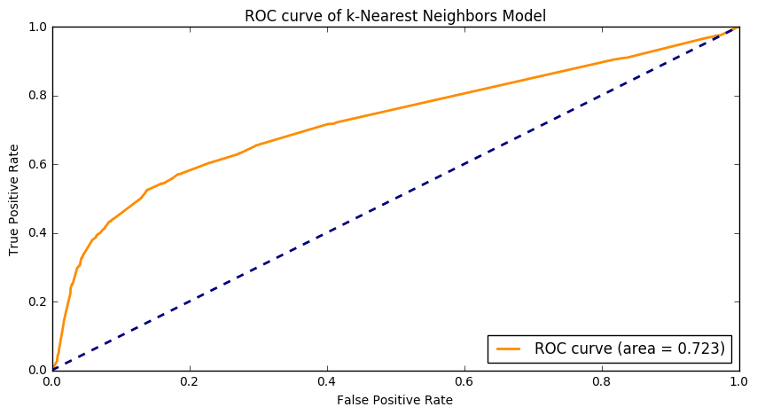

```python
kNN_model = KNeighborsClassifier(n_neighbors=50, weights='distance')
s = evalute_model(kNN_model, TAG="k-Nearest Neighbors Model", data_selection="0000100", draw_CONFUSION_MATRIX=True, draw_ROC=True)
```

# Naive Bayes

```
========== Naive Bayes(Gaussian) Model ==========
Accuracy:   0.806333 / Precision:   0.577586 / Recall:   0.410413 / F1 Score:   0.479857
Accuracy:   0.800667 / Precision:   0.580623 / Recall:   0.413912 / F1 Score:   0.483295
Accuracy:   0.803333 / Precision:   0.555476 / Recall:   0.400728 / F1 Score:   0.465580
AVG SCORE in 3 runs: 0.803444444444
=================================================
```

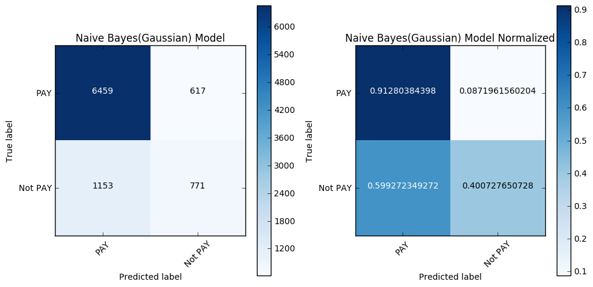

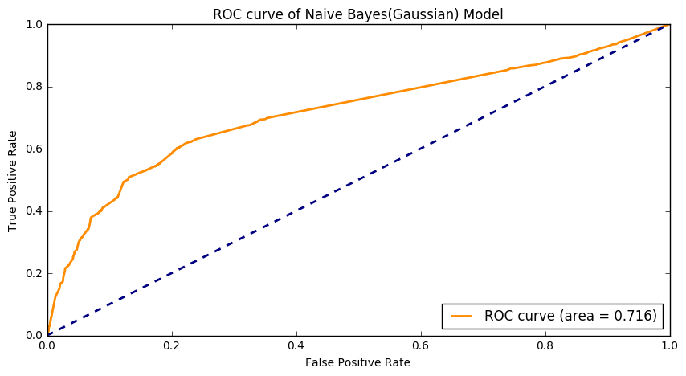

```python
NB_model = GaussianNB()
s = evalute_model(NB_model, TAG="Naive Bayes(Gaussian) Model", data_selection="0000100", draw_CONFUSION_MATRIX=True, draw_ROC=True)
```

```
========== Naive Bayes(Bernoulli) Model ==========
Accuracy:   0.789889 / Precision:   0.563095 / Recall:   0.449834 / F1 Score:   0.500132
Accuracy:   0.800556 / Precision:   0.544197 / Recall:   0.466014 / F1 Score:   0.502080
Accuracy:   0.788889 / Precision:   0.548599 / Recall:   0.445952 / F1 Score:   0.491979
AVG SCORE in 3 runs: 0.793111111111
==================================================
```

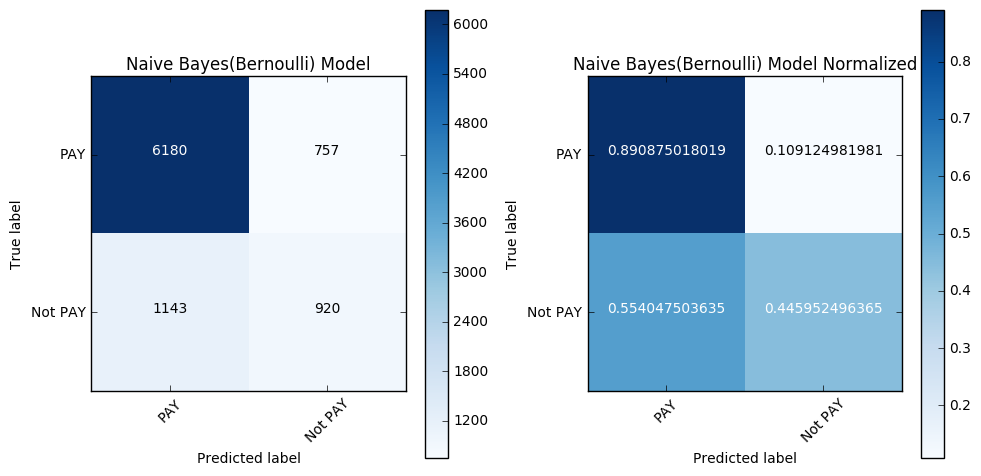

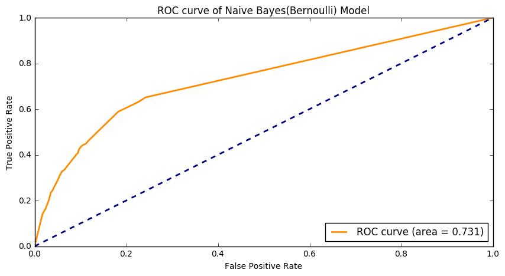

```python
NB_model = BernoulliNB(alpha=0.5)
s = evalute_model(NB_model, TAG="Naive Bayes(Bernoulli) Model", data_selection="0000100", draw_CONFUSION_MATRIX=True, draw_ROC=True)
```

# Random Forest

```
========== Random Forest Model ==========
Accuracy:   0.822222 / Precision:   0.685315 / Recall:   0.348047 / F1 Score:   0.461642
Accuracy:   0.824444 / Precision:   0.696482 / Recall:   0.351598 / F1 Score:   0.467296
Accuracy:   0.822778 / Precision:   0.677073 / Recall:   0.354443 / F1 Score:   0.465303
AVG SCORE in 3 runs: 0.823148148148
=========================================
```

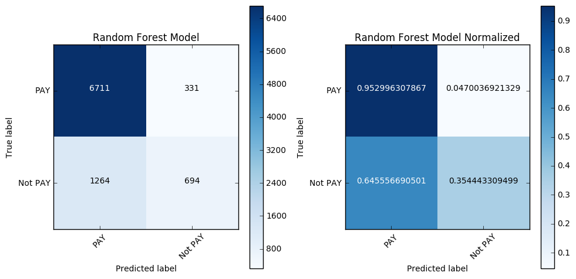

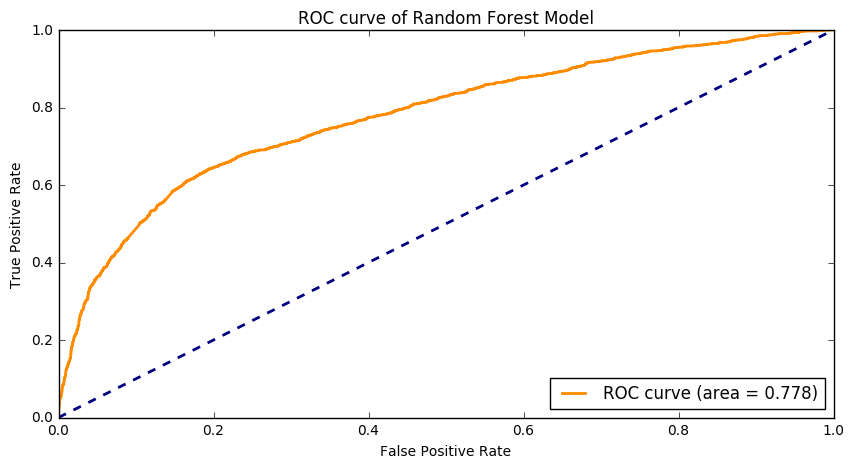

```python
RF_model = RandomForestClassifier(n_estimators=70, max_depth=10, criterion="gini")
s = evalute_model(RF_model, TAG="Random Forest Model", data_selection="0000111", draw_CONFUSION_MATRIX=True, draw_ROC=True)
```

# SVM

### Perform Search to find best C and Gamma

```python
# Perform Grid Search
Grid_Result = []
for x in range(0,5):
    Step_Result = []
    for y in range(0,5):
        SVM_model_t = SVC(C=10**x, gamma=0.5**y)
        s = evalute_model(SVM_model_t, RUNS=1, TAG="SVM Model "+str(x)+" "+str(y), data_selection="0100100", SCALE=True)
        print(datetime.now())
        Step_Result.append(s)
    Grid_Result.append(Step_Result)
```

```
========== SVM Model 0 0 ==========
Accuracy:   0.820111 / Precision:   0.654842 / Recall:   0.351699 / F1 Score:   0.457621
AVG SCORE in 1 runs: 0.820111111111
===================================
2016-10-31 22:14:04.279377
========== SVM Model 0 1 ==========
Accuracy:   0.817000 / Precision:   0.658982 / Recall:   0.346815 / F1 Score:   0.454455
AVG SCORE in 1 runs: 0.817
===================================
2016-10-31 22:14:14.848071
========== SVM Model 0 2 ==========
Accuracy:   0.816556 / Precision:   0.671583 / Recall:   0.341500 / F1 Score:   0.452768
AVG SCORE in 1 runs: 0.816555555556
===================================
2016-10-31 22:14:25.993617
========== SVM Model 0 3 ==========
Accuracy:   0.828333 / Precision:   0.685047 / Recall:   0.377640 / F1 Score:   0.486881
AVG SCORE in 1 runs: 0.828333333333
===================================
2016-10-31 22:14:38.006782
========== SVM Model 0 4 ==========
Accuracy:   0.820222 / Precision:   0.687885 / Recall:   0.337702 / F1 Score:   0.453009
AVG SCORE in 1 runs: 0.820222222222
===================================
2016-10-31 22:14:50.467053
========== SVM Model 1 0 ==========
Accuracy:   0.818667 / Precision:   0.648780 / Recall:   0.343314 / F1 Score:   0.449021
AVG SCORE in 1 runs: 0.818666666667
===================================
2016-10-31 22:15:01.303784
========== SVM Model 1 1 ==========
Accuracy:   0.817222 / Precision:   0.667585 / Recall:   0.361692 / F1 Score:   0.469184
AVG SCORE in 1 runs: 0.817222222222
===================================
2016-10-31 22:15:12.580160
========== SVM Model 1 2 ==========
Accuracy:   0.818000 / Precision:   0.669573 / Recall:   0.378885 / F1 Score:   0.483932
AVG SCORE in 1 runs: 0.818
===================================
2016-10-31 22:15:26.294518
```

[output cut: 65 more lines]

```
========== SVM Model 4 1 ==========
Accuracy:   0.808222 / Precision:   0.610517 / Recall:   0.347011 / F1 Score:   0.442506
AVG SCORE in 1 runs: 0.808222222222
===================================
2016-10-31 22:28:59.788368
========== SVM Model 4 2 ==========
Accuracy:   0.815111 / Precision:   0.628848 / Recall:   0.365355 / F1 Score:   0.462185
AVG SCORE in 1 runs: 0.815111111111
===================================
2016-10-31 22:29:33.518162
========== SVM Model 4 3 ==========
Accuracy:   0.812889 / Precision:   0.639699 / Recall:   0.343261 / F1 Score:   0.446781
AVG SCORE in 1 runs: 0.812888888889
===================================
2016-10-31 22:35:33.589568
```

```
========== SVM Model ==========
Accuracy:   0.819667 / Precision:   0.680664 / Recall:   0.349724 / F1 Score:   0.462048
Accuracy:   0.824444 / Precision:   0.689370 / Recall:   0.343092 / F1 Score:   0.458162
Accuracy:   0.818333 / Precision:   0.663690 / Recall:   0.340458 / F1 Score:   0.450050
AVG SCORE in 3 runs: 0.820814814815
===============================
```

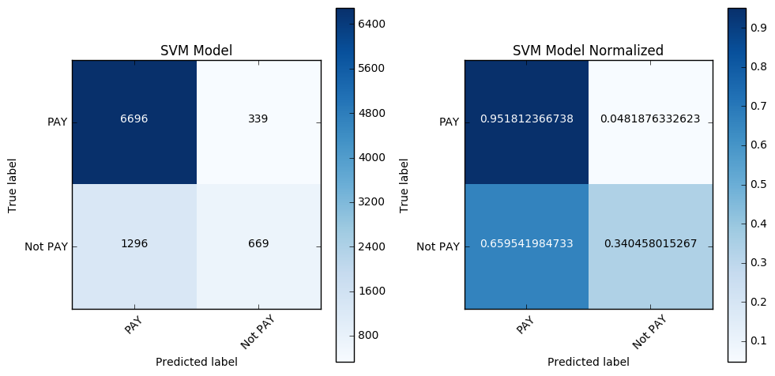

```python
SVM_model = SVC(C=10**1, gamma=0.5**4)
s = evalute_model(SVM_model, TAG="SVM Model", data_selection="0100100", SCALE=True, draw_CONFUSION_MATRIX=True, RUNS=3)
```

# Bagging

```
========== Bagging Model ==========
Accuracy:   0.816000 / Precision:   0.645925 / Recall:   0.370538 / F1 Score:   0.470927
Accuracy:   0.815000 / Precision:   0.642857 / Recall:   0.362720 / F1 Score:   0.463768
Accuracy:   0.818444 / Precision:   0.661172 / Recall:   0.363545 / F1 Score:   0.469136
AVG SCORE in 3 runs: 0.816481481481
===================================
```

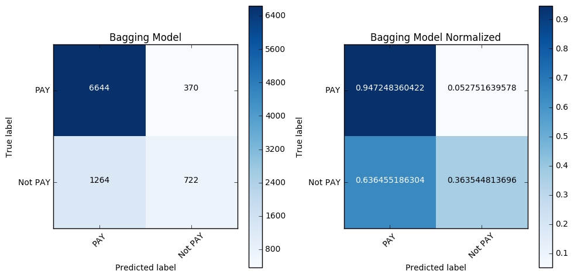

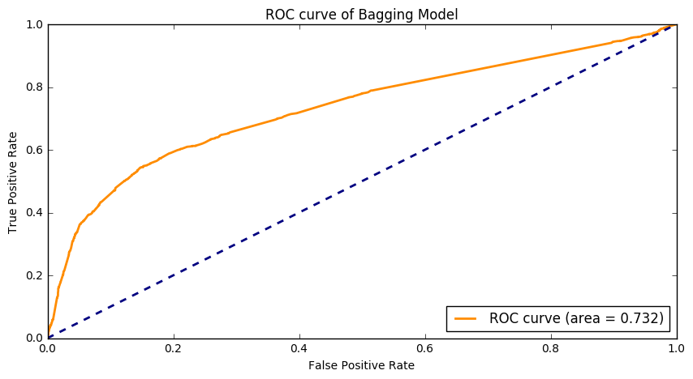

```python
BAG_model = BaggingClassifier(n_estimators=70)
s = evalute_model(BAG_model, TAG="Bagging Model", data_selection="0000100", draw_CONFUSION_MATRIX=True, draw_ROC=True, RUNS=3)
```

# AdaBoost

```
========== ADA BOOST Model ==========
Accuracy:   0.820889 / Precision:   0.694006 / Recall:   0.333165 / F1 Score:   0.450205
Accuracy:   0.819444 / Precision:   0.693835 / Recall:   0.332665 / F1 Score:   0.449712
Accuracy:   0.817000 / Precision:   0.693059 / Recall:   0.319021 / F1 Score:   0.436923
AVG SCORE in 3 runs: 0.819111111111
=====================================
```

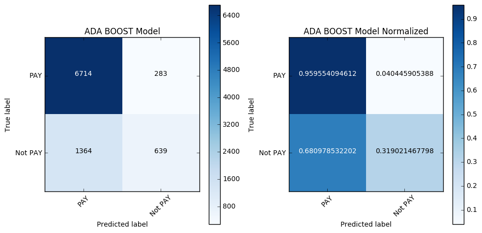

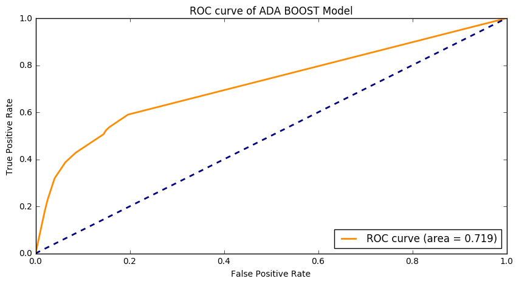

```python
ADA_model = AdaBoostClassifier(n_estimators=100, learning_rate=0.01)
s = evalute_model(ADA_model, TAG="ADA BOOST Model", data_selection="1101111", draw_CONFUSION_MATRIX=True, draw_ROC=True, RUNS=3)
```

# ExtraTrees

```
========== Extra Tress Model ==========
Accuracy:   0.823000 / Precision:   0.665187 / Recall:   0.381170 / F1 Score:   0.484633
Accuracy:   0.821000 / Precision:   0.666079 / Recall:   0.380282 / F1 Score:   0.484150
Accuracy:   0.820444 / Precision:   0.669084 / Recall:   0.371041 / F1 Score:   0.477361
AVG SCORE in 3 runs: 0.821481481481
=======================================
```

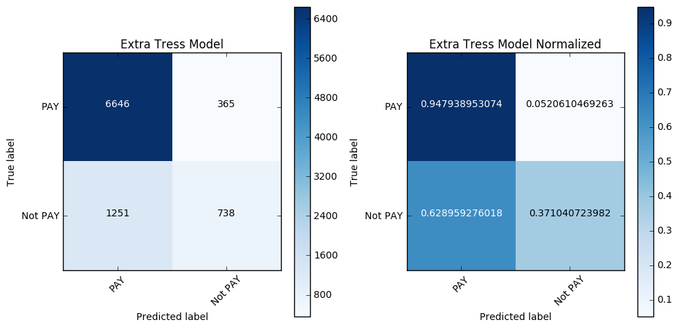

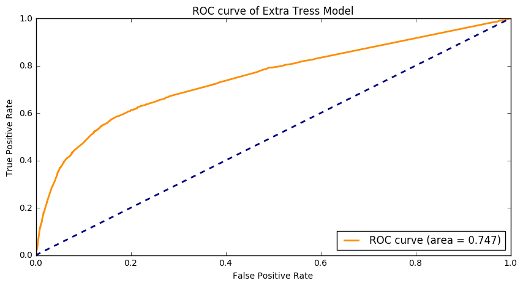

```python
ET_model = ExtraTreesClassifier(n_estimators=70, max_depth=10)
s = evalute_model(ET_model, TAG="Extra Tress Model", data_selection="0000100", draw_CONFUSION_MATRIX=True, draw_ROC=True, RUNS=3)
```

# Muti Layer Perceptron

```
========== Muti Layer Perceptron Model ==========
Accuracy:   0.828111 / Precision:   0.683203 / Recall:   0.398882 / F1 Score:   0.503689
Accuracy:   0.819556 / Precision:   0.670203 / Recall:   0.377302 / F1 Score:   0.482803
Accuracy:   0.822000 / Precision:   0.670330 / Recall:   0.370821 / F1 Score:   0.477495
AVG SCORE in 3 runs: 0.823222222222
=================================================
```

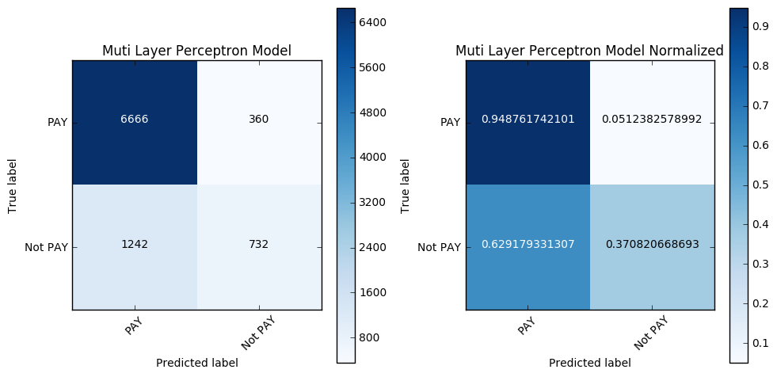

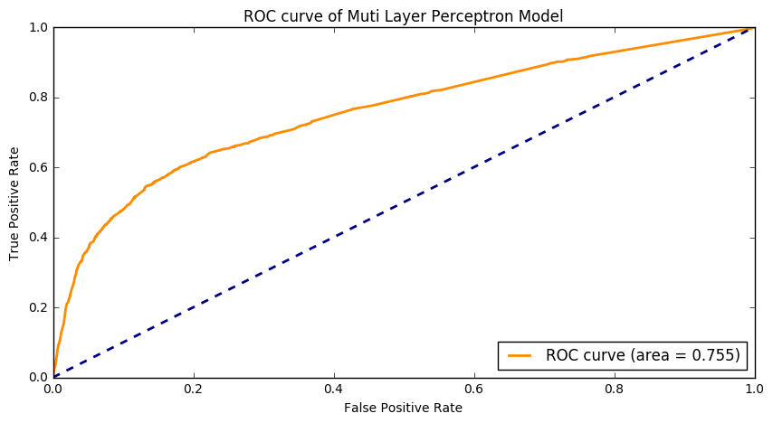

```python
MLP_model = MLPClassifier(hidden_layer_sizes=(50,), activation="relu")
s = evalute_model(MLP_model, TAG="Muti Layer Perceptron Model", data_selection="0100100", draw_CONFUSION_MATRIX=True, draw_ROC=True, RUNS=3)
```

# Hard Voting

```
========== VC Model ==========
Accuracy:   0.815444 / Precision:   0.676083 / Recall:   0.352826 / F1 Score:   0.463675
Accuracy:   0.827444 / Precision:   0.672691 / Recall:   0.353189 / F1 Score:   0.463187
Accuracy:   0.817444 / Precision:   0.687685 / Recall:   0.344862 / F1 Score:   0.459362
AVG SCORE in 3 runs: 0.820111111111
==============================
```

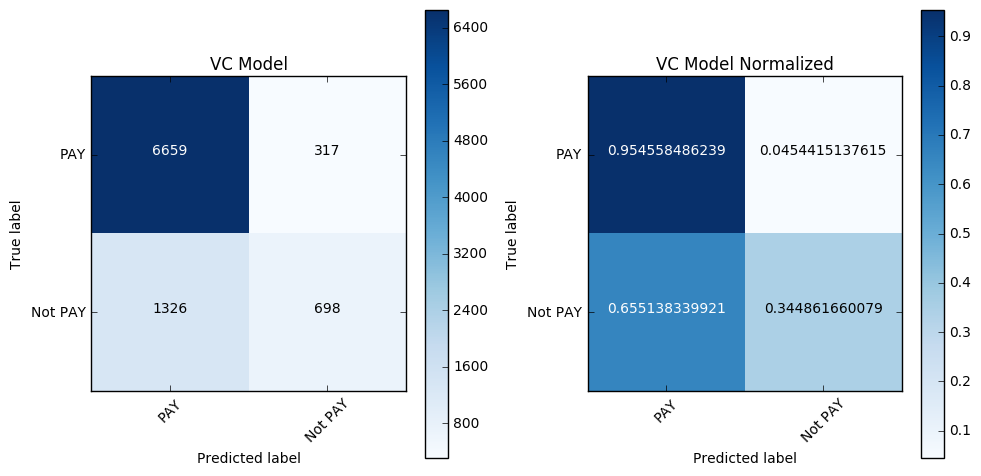

```python
RF_model = RandomForestClassifier(n_estimators=70, max_depth=10, criterion="gini")
KNN_model = KNeighborsClassifier(n_neighbors=50, weights='distance')
LR_model = LogisticRegression(penalty='l2', C=1000)
BAG_model = BaggingClassifier(n_estimators=70)
EXT_model = ExtraTreesClassifier(n_estimators=70, max_depth=10)
MLP_model = MLPClassifier(hidden_layer_sizes=(50,), activation="relu")

VC_model = VotingClassifier(estimators=[('rf',RF_model),('knn',KNN_model),('lr',LR_model),('BAG',BAG_model),('EXT',EXT_model),('MLP',MLP_model)])

s = evalute_model(VC_model, TAG="VC Model", data_selection="0100100", draw_CONFUSION_MATRIX=True, RUNS=3)
```

# Some conclusions on classification

### The choice of attributes

- Gender might have some influence on default payment
- Education and Marriage does not have so much an influence on default payment
- Choosing only the History of past payment usually gives the best results in most models, while sex and age will sometimes help

### What shall be the lower bound of the score?

- A random guess shall have an accuracy of about 50%
- A dummy Classifer that respecting the training set’s class distribution will have an accuracy of about 65%
- A dummy Classifer that guess all zeros will have an accuracy of about 77.88%

### The fight for Accuracy

- The accuracy is mostly influenced by the indentification of the delay payment entries
- In most conditions the higher the Recall the better the accuracy
- We can get a sense of it from the CONFUSION_MATRIX
- Most Methods can get to a accuracy of 80% after some fine tuning
- I get at most 82.8% accuracy, using all the methods I tried

# Clustering

- I choose to test from K=1 to k=24
- Gender(2) * Education(4) * Marital status(3) = 24 kinds
- Education(others) and Marital status(others) only have a percentage of 1% of data
- Gender(2) * Education(3) * Marital status(2) = 12 kinds

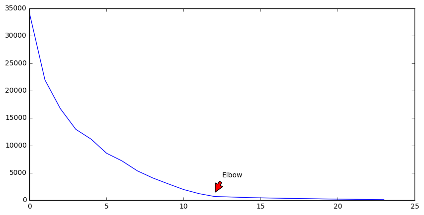

```python
# Clustering Data Pre-process
clustering_data = raw_data[['SEX', 'EDUCATION', 'MARRIAGE']]

# Draw and find the elbow
km_list = []
for i in range(1,25):
    c, l, inertia = k_means(clustering_data, i)
    km_list.append(inertia)
plt.plot(km_list)
plt.annotate('Elbow', xy=(12, km_list[11]), xytext=(12.5, km_list[11]+3000), arrowprops=dict(facecolor='red', shrink=0.1))
plt.show()
```

- We can observe the elbow at about k=12
- Which matches my initial guess since others only show up in a small part of the data